# Homework Nubank 2019

This markdown contains the following sections:

1. Puzzle Overview
2. Libraries
3. Reading the Datasets
4. Data Cleaning
5. Exploratory Data Analysis
6. Modeling
7. Conclusions

## Puzzle Overview

As a credit company, it is important to know beforehand who is able to pay their loans and who is not. The goal of this puzzle is to build a statistical/machine learning model to figure out which clients are able to honor their debt.

The goal is to predict the probability of default, which is identified by the *default* variable in the training set. Thus, we are dealing with a **supervised** problem for a **binary classification** but rather than classes, the output should be the **probability.** The models tested in this notebook are the Logistic Regression and Random Forest.

## Libraries

The following libraries are required to run all the code presented in this notebook.

```r
library(knitr) # Markdown, LaTeX, HTML
library(dplyr) # data manipulation
library(ggplot2) # plots
library(caret) # classification and regression training
library(kableExtra)
library(corrplot) # for correlation plot
library(tidyr)
library(randomForest)
library(ROCR)
library(partykit)
library(naniar)
library(xgboost)
```

## Reading the Datasets

```r
# Reading the csv format data
train <- read.csv('puzzle_train_dataset.csv')
test <- read.csv('puzzle_test_dataset.csv')

head(train,2) %>%
  kable(caption='Train Dataset') %>%
  kable_styling() %>%
  scroll_box(width = '100%') # adding a scroll bar as it has many columns
```

Train Dataset

| ids | default | score_1 | score_2 | score_3 | score_4 | score_5 | score_6 | risk_rate | amount_borrowed | borrowed_in_months | credit_limit | reason | income | sign | gender | facebook_profile | state | zip | channel | job_name | real_state | ok_since | n_bankruptcies | n_defaulted_loans | n_accounts | n_issues |
| --- | --- | --- | --- | --- | --- | --- | --- | --- | --- | --- | --- | --- | --- | --- | --- | --- | --- | --- | --- | --- | --- | --- | --- | --- | --- | --- |
| 810e3277-619e-3154-7ba0-ebddfc5f7ea9 | False | smzX0nxh5QlePvtVf6EAeg== | tHpS8e9F8d9zg3iOQM9tsA== | 710 | 104.1750 | 0.6615086 | 123.0153 | 0.43 | 20024.31 | 60 | 62386 | mLVIVxoGY7TUDJ1FyFoSIZi1SFcaBmO01AydRchaEiGYtUhXGgZjtNQMnUXIWhIhmLVIVxoGY7TUDJ1FyFoSIZi1SFcaBmO01AydRchaEiFzLXZNLyvbNs/gWFaHYSlv | 59869.05 | virg | f | True | xsd3ZdsI3356I3xMxZeiqQ== | i036nmJ7rfxo+3EvCD7Jnw== | NCqL3QBx0pscDnx3ixKwXg== | mLVIVxoGY7TUDJ1FyFoSIZi1SFcaBmO01AydRchaEiGYtUhXGgZjtNQMnUXIWhIhmLVIVxoGY7TUDJ1FyFoSIU6/nAzyh3ze+CBMzoYhVLg= | n+xK9CfX0bCn77lClTWviw== | 14 | 1 | 0 | 9 | 9 |
| b4118fd5-77d5-4d80-3617-bacd7aaf1a88 | False | DGCQep2AE5QRkNCshIAlFQ== | RO7MTL+j4PH2gNzbhNTq/A== | 330 | 97.8808 | 0.5311155 | 110.9135 | 0.23 | 10046.51 | 36 | NA | mLVIVxoGY7TUDJ1FyFoSIZi1SFcaBmO01AydRchaEiGYtUhXGgZjtNQMnUXIWhIhmLVIVxoGY7TUDJ1FyFoSIRnhxgN2wGSznGRSVzckUrzPiO4/8HgZtQjTkkzkxoTJ | 46016.31 | sagi | f | False | xsd3ZdsI3356I3xMxZeiqQ== | oyrt7nHjoQSc58vCxgJF/w== | NCqL3QBx0pscDnx3ixKwXg== | mLVIVxoGY7TUDJ1FyFoSIZi1SFcaBmO01AydRchaEiGYtUhXGgZjtNQMnUXIWhIhkcGmRsnH2PPk1/G0Vqo9dliQr5fVUv6Nb3z4cdALTys= | n+xK9CfX0bCn77lClTWviw== | 75 | 0 | 0 | 3 | NA |

## Data Cleaning

We have 64592 rows in the train dataset with 27 columns. There are some numerical and some categorical variables. Let’s take a look at what these variables looks like.

```r
# Creating a summary dataframe
summary_df <- data.frame('var' = names(train),
                         'type' = as.character(lapply(train, class)),
                         'unique' = as.character(lapply(train, function(x) length(unique(x)))),
                         'count_na_values' = as.character(lapply(train, function(x) sum(is.na(x)))),
                         'first_obs' = as.character(lapply(train, function(x) as.character(first(x)))))

summary_df %>%
  kable(caption='Variables Summary') %>%
  kable_styling() %>%
  scroll_box(width = '100%', height = '400px')
```

Variables Summary

| var | type | unique | count_na_values | first_obs |
| --- | --- | --- | --- | --- |
| ids | factor | 64592 | 0 | 810e3277-619e-3154-7ba0-ebddfc5f7ea9 |
| default | factor | 3 | 0 | False |
| score_1 | factor | 8 | 0 | smzX0nxh5QlePvtVf6EAeg== |
| score_2 | factor | 36 | 0 | tHpS8e9F8d9zg3iOQM9tsA== |
| score_3 | numeric | 89 | 785 | 710 |
| score_4 | numeric | 64592 | 0 | 104.174960753 |
| score_5 | numeric | 64592 | 0 | 0.661508561544 |
| score_6 | numeric | 64592 | 0 | 123.01532541 |
| risk_rate | numeric | 83 | 785 | 0.43 |
| amount_borrowed | numeric | 53349 | 785 | 20024.31 |
| borrowed_in_months | numeric | 3 | 785 | 60 |
| credit_limit | numeric | 28260 | 19753 | 62386 |
| reason | factor | 20346 | 0 | mLVIVxoGY7TUDJ1FyFoSIZi1SFcaBmO01AydRchaEiGYtUhXGgZjtNQMnUXIWhIhmLVIVxoGY7TUDJ1FyFoSIZi1SFcaBmO01AydRchaEiFzLXZNLyvbNs/gWFaHYSlv |
| income | numeric | 57431 | 785 | 59869.05 |
| sign | factor | 13 | 0 | virg |
| gender | factor | 3 | 0 | f |
| facebook_profile | factor | 3 | 0 | True |
| state | factor | 51 | 0 | xsd3ZdsI3356I3xMxZeiqQ== |
| zip | factor | 831 | 0 | i036nmJ7rfxo+3EvCD7Jnw== |
| channel | factor | 2 | 0 | NCqL3QBx0pscDnx3ixKwXg== |
| job_name | factor | 44605 | 0 | mLVIVxoGY7TUDJ1FyFoSIZi1SFcaBmO01AydRchaEiGYtUhXGgZjtNQMnUXIWhIhmLVIVxoGY7TUDJ1FyFoSIU6/nAzyh3ze+CBMzoYhVLg= |
| real_state | factor | 6 | 0 | n+xK9CfX0bCn77lClTWviw== |
| ok_since | numeric | 105 | 38038 | 14 |
| n_bankruptcies | numeric | 8 | 987 | 1 |
| n_defaulted_loans | numeric | 6 | 803 | 0 |
| n_accounts | numeric | 46 | 785 | 9 |
| n_issues | numeric | 46 | 16451 | 9 |

Looking at the number of unique values for each feature, we can already tell that each row represents an unique client (*ids*). Note also that there are some encrypted variables. We also have some missing values, marked on the *count_na_values* column. We also see that the variable *borrowed_in_months* is numerical but only has 3 values, so it may be better to use it as a categorical variable.

```r
train$borrowed_in_months <- as.factor(train$borrowed_in_months)
test$borrowed_in_months <- as.factor(test$borrowed_in_months)
```

Our dependent variable (target) is *default*, which is a boolean value. However, we see that there are 3 levels. Inspecting, we find that there are empty inputs creating a “” level, and that this occurs to every factor variable except the *ids* column. These will be treated as missing values, as it makes no sense in none of the features, and is dangerous to keep it this way as it could lead to the model using all n dummy variables instead of (n-1).

```r
# Structure of the categorical variables
str(select_if(train, is.factor)) # Undesirable empty level ""
```

```
## 'data.frame':    64592 obs. of  14 variables:
##  $ ids               : Factor w/ 64592 levels "0003da40-123b-031a-63b3-f7c9f18516ab",..: 32384 45216 42081 10012 58038 46291 34788 46446 24902 2253 ...
##  $ default           : Factor w/ 3 levels "","False","True": 2 2 2 2 2 2 2 2 2 2 ...
##  $ score_1           : Factor w/ 8 levels "","1Rk8w4Ucd5yR3KcqZzLdow==",..: 8 5 4 3 3 2 5 8 2 5 ...
##  $ score_2           : Factor w/ 36 levels "","/tdlnWjXoZ3OjdtBXzdOJQ==",..: 30 28 35 31 9 27 28 11 14 17 ...
##  $ borrowed_in_months: Factor w/ 2 levels "36","60": 2 1 2 1 1 1 1 2 2 1 ...
##  $ reason            : Factor w/ 20346 levels "","mLVIVxoGY7TUDJ1FyFoSIajntNuP9+k+0GkZRAvieTPJZitTdV5z59z5/uk4C6+fZXU2S3kiwPuazYT7i37CXbRGYQtX88kfDD9crRqaZ23MJ+w"| __truncated__,..: 14192 5304 12393 16087 15027 5682 16017 11781 7912 8461 ...
##  $ sign              : Factor w/ 13 levels "","aqua","arie",..: 13 10 8 1 8 1 13 1 1 1 ...
##  $ gender            : Factor w/ 3 levels "","f","m": 2 2 3 3 3 2 3 3 2 2 ...
##  $ facebook_profile  : Factor w/ 3 levels "","False","True": 3 2 3 2 1 2 2 3 2 3 ...
##  $ state             : Factor w/ 51 levels "","/+QaZYcpPt5mXLpkv6I8Bw==",..: 46 46 5 27 41 8 4 31 18 18 ...
##  $ zip               : Factor w/ 831 levels "","/+82UC3tzFrNWWenFmhJGg==",..: 365 552 192 212 781 590 756 348 579 275 ...
##  $ channel           : Factor w/ 2 levels "","NCqL3QBx0pscDnx3ixKwXg==": 2 2 2 2 2 2 2 2 2 2 ...
##  $ job_name          : Factor w/ 44605 levels "","75/c/HDAyPpsM73zIdA1jDXtf2PwTDRY6jnSMMyozRMoC1kOfWpg5CMMjkzL06RbFBpFI+bOjpbL81eMKYQpn7rWti3gS2ZrYcVIAr01+xE=",..: 27190 14697 34788 8104 33441 340 1 25418 23377 36670 ...
##  $ real_state        : Factor w/ 6 levels "","+qWF9pJpVGtTFn4vFjb/cg==",..: 3 3 4 4 4 3 4 4 4 4 ...
```

```r
summary(train$default) # count of each level in the target variable
```

```
##       False  True
##  4626 50456  9510
```

```r
# Number of empty cells in the train dataset
sum(train=="", na.rm = T)
```

```
## [1] 49282
```

```r
# Creating a functin to clean the empty values, as it needs to be applied to both train and test dataset
cleaning_empty_levels <- function(data) {
  data[data==""] <- NA

  # Removing "" levels from factors
  for (column in names(select_if(data, is.factor))) {
    data[,column] <- droplevels(data[,column])
  }

  return(data)
}

train <- cleaning_empty_levels(train)
test <- cleaning_empty_levels(test)
```

We will also remove the rows that the *default* variable is NA, as the model can’t learn anything from them.

```r
train <- train[-which(is.na(train$default)),]
```

## Exploratory Data Analysis

### Correlation

From the correlation plot of the numerical variables, we see that the the variables *n_accounts* and *n_issues* are highly correlated, with a value of 0.9992. Other than that, we don’t see any strong correlation between other variables.

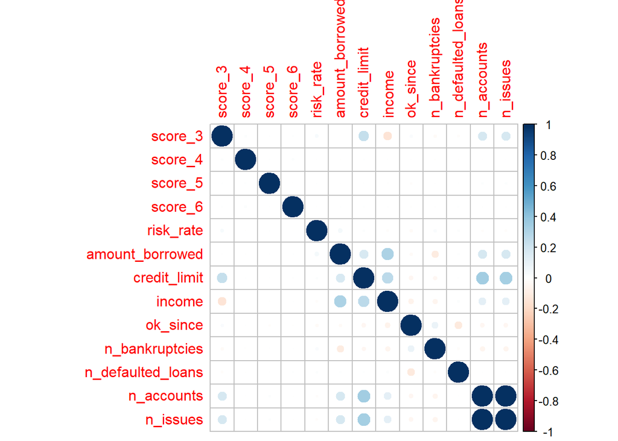

```r
corrplot(cor(select_if(train, is.numeric), use = "complete.obs"))
```

### Missing Values

```r
round(sapply(train, function(x) sum(is.na(x)))/nrow(train), 3)
```

```
##                ids            default            score_1
##              0.000              0.000              0.000
##            score_2            score_3            score_4
##              0.000              0.000              0.000
##            score_5            score_6          risk_rate
##              0.000              0.000              0.000
##    amount_borrowed borrowed_in_months       credit_limit
##              0.000              0.000              0.313
##             reason             income               sign
##              0.000              0.000              0.316
##             gender   facebook_profile              state
##              0.050              0.100              0.000
##                zip            channel           job_name
##              0.000              0.000              0.063
##         real_state           ok_since     n_bankruptcies
##              0.000              0.585              0.003
##  n_defaulted_loans         n_accounts           n_issues
##              0.000              0.000              0.260
```

```r
train <- train[,-which(names(train) %in% c("ok_since","channel", "sign", "n_issues"))]
```

### Distributions

Looking at the density of the numerical variables, we see that some are highly skewed. We may want to look closer as we may find some potential outliers.

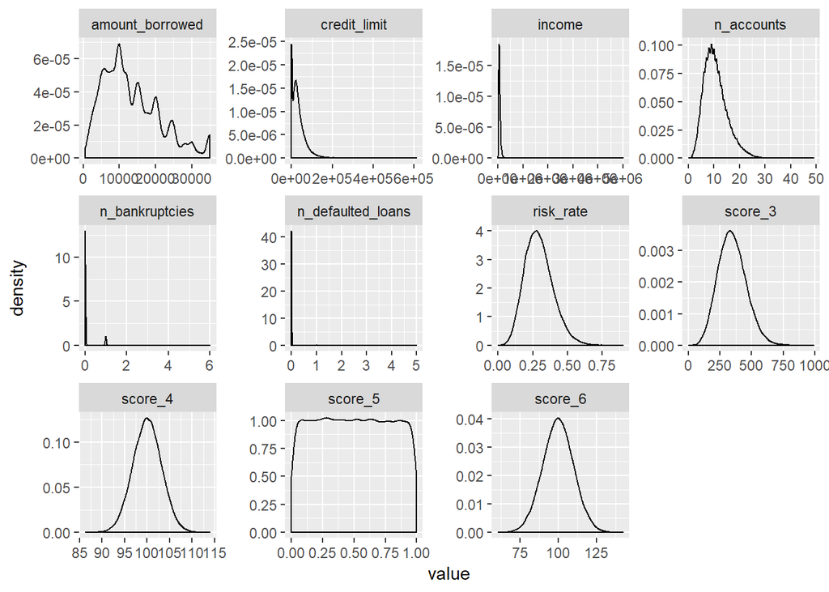

```r
select_if(train, is.numeric) %>%
  gather() %>%
  ggplot(aes(value)) +
  facet_wrap(~ key, scales='free') +
  geom_density()
```

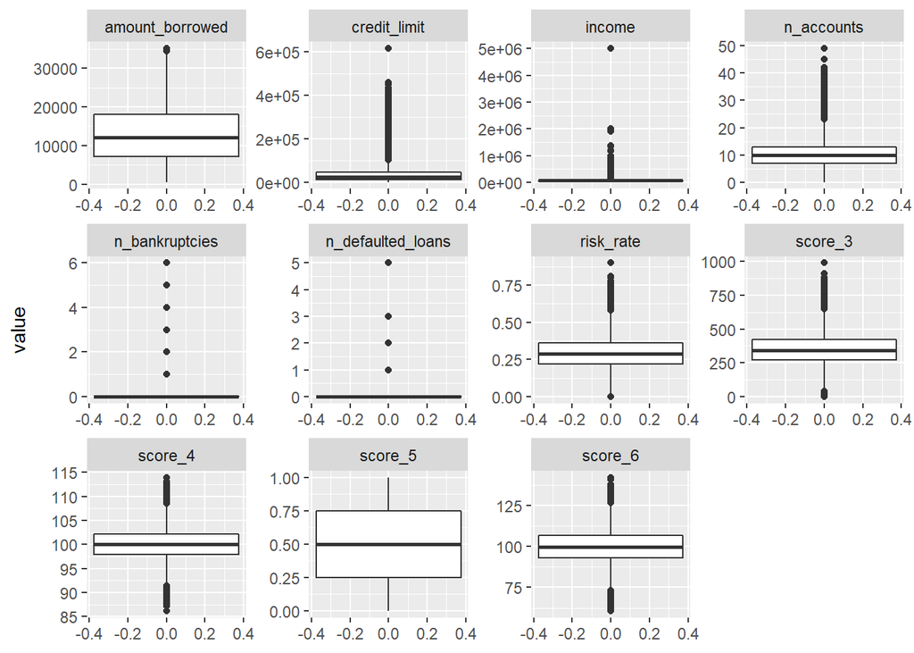

```r
select_if(train, is.numeric) %>%
  gather() %>%
  ggplot(aes(y=value)) +
  facet_wrap(~ key, scales='free') +
  geom_boxplot()
```

*n_bankruptcies* and *n_defaulted_loans* are discrete and have very low representation of higher values. Let’s change it to binary variables instead.

```r
train$n_bankruptcies <- as.factor(ifelse(train$n_bankruptcies==0,0,1))
train$n_defaulted_loans <- as.factor(ifelse(train$n_defaulted_loans==0,0,1))
test$n_bankruptcies <- as.factor(ifelse(test$n_bankruptcies==0,0,1))
test$n_defaulted_loans <- as.factor(ifelse(test$n_bankruptcies==0,0,1))
```

## Modeling

As the No Free Lunch theorem states, there is no such thing as “the best model”. So we will build a Logistic Regression and a Random Forest and evaluate them to find the optimal one for our problem.

We also need to be aware of how the dataset is **imbalanced** with respect to the target variable, as only 16% of the target is labeled *True.* This needs to be taken into account as looking only at metrics like Accuracy may not be a good indicator, alternatively, we should look at a good tradeoff between Sensitivity and Specificity.

```r
summary(train$default)
```

```
## False  True
## 50456  9510
```

### Metrics

As our goal is to predict the probability of default, that is, the probability of the output being of the class *True*, the following metrics will be used to evaluate our models: AUC (Area Under the ROC Curve) and the Log Loss Score.

```r
# Log Loss
logLoss <- function(pred, actual){
  ll <- -1*mean(log(pred[model.matrix(~ actual + 0) - pred > 0]))
  return(round(ll,3))
}

# ROC and AUC
roc_auc <- function(pred, actual) {
  metrics <- ROCR::prediction(pred, actual)

  perf <- performance(metrics, measure="tpr",
                    x.measure="fpr")
  auc <- performance(metrics, measure="auc")

  return(plot(perf, main = paste0("AUC: ", auc@y.values)) + abline(a=0,b=1))
}

# AUC
auc <- function(pred, actual) {
  metrics <- ROCR::prediction(pred, actual)
  auc <- performance(metrics, measure="auc")
  return(round(unlist(auc@y.values),3))
}
```

We could additionally look at how it performs as a binary classifier, with metrics like Recall, Precision, F1-Score and Confusion Matrix. We would however need to define a threshold on this case.

### Handling with Imbalanced Dataset

As stated, we should be cautious with the fact that the 2 classes on the target variable aren’t equally represented on the dataset. A simple way to overcome this is to use resampling methods like Undersampling and Oversampling. Because we don’t have much data, we’ll go with the latter. Another good way to handle this is by defining a cost function. We first need to wonder if classifying a customer as default when in reality he is not is better than the other way around. But because this needs more understanding of the business, I’ll leave it as a side note.

Let’s change the target to 0 and 1 to make it easier for further evaluations.

```r
train$default <- ifelse(train$default=='True',1,0)
train$default <- as.factor(train$default)
```

### Cross Validation

The first step is to split the train dataset into the train the model will receive as input and a holdout validation dataset to evaluate the quality of the model on unseen data. We’ll use a 70-30 split.

```r
set.seed(123)

train_idx <- sample(nrow(train), nrow(train)*0.7)
test_idx <- setdiff(seq(1, nrow(train)), train_idx)

validation <- train[test_idx,]
train <- train[train_idx,]
```

Now, we need to do an oversample of out training dataset so that the model won’t be biased by the majority class. A side note to oversampling however is that it can lead to overfitting, as it adds replicated observations in the original data set.

```r
set.seed(456)
dados0 <- subset(train, train$default==0)
dados1 <- subset(train, train$default==1)
amostra0 <- sample(nrow(dados0), nrow(dados0))
amostra1 <- sample(nrow(dados1), nrow(dados0), replace = TRUE)

amostra0 <- dados0[amostra0,]
amostra1 <- dados1[amostra1,]

sample_data <- rbind(amostra0, amostra1)
rm(amostra0, amostra1)
```

### Logistic Regression

As the desired output is the probability, we’ll start by modeling a Logistic Regression with a Stepwise Feature Selection.

The features *job_name*, *reason*, *zip* and *state* have too many levels, and a more deep analysis would be needed to see if it could be broken down into smaller levels (perhaps in a clustering analysis) and if it would be worth it. As for in this project, it will be leaved out.

A transformation on the variables *credit_limit* and *income* were made to try to make it fit better, in an attempt to make their skewness lower.

```r
full <- default ~ score_1 + score_2 + score_3 + score_4 + score_5 + score_6 + risk_rate + amount_borrowed + borrowed_in_months + sqrt(credit_limit) + log(income) + gender + facebook_profile + real_state + n_bankruptcies + n_defaulted_loans + n_accounts

glm <- glm(full, sample_data, family=binomial())

glm <- step(glm, trace=FALSE)

formula <- glm$formula

pred_glm <- predict(glm, validation, type='response')

# Metrics
auc_glm <- auc(pred_glm, validation$default)
logloss_glm <- logLoss(pred_glm[-which(is.na(pred_glm))],
                       ifelse(validation$default==0,0,1)[-which(is.na(pred_glm))])
```

### Logistic Regression with Binary Predictors

Another Logistic Regression was tested but only with binary variables. A decision tree was built to every variable in the dataset and its splits were made to categorize the numerical variables and reduce the levels of the categories with high dimensionality. Unfortunatly, it took way too much time to process the tree for categories with more than 30 levels, so that was left out. This served more of a test, and it didn’t give any improvement to the last model.

```r
binary_transf <- function(data) {
  binary_data <- data.frame('default'=data$default)

  for (var in c('score_1','score_3','score_4','score_5','score_6','risk_rate','amount_borrowed','borrowed_in_months','credit_limit','income','gender','facebook_profile','real_state','n_bankruptcies','n_defaulted_loans','n_accounts')) {

    # Decision Trees to find splitting rules
    tree <- partykit::ctree(default~eval(parse(text=var)), sample_data)
    rules <- list(partykit:::.list.rules.party(tree))
    if (length(unlist(rules))>1) {
      for (i in 1:(length(unlist(rules))-1)) {
        newVar <- paste0(var,'_',i)
        binary <- data %>%
          mutate(newVar=ifelse(eval(parse(text = unlist(rules)[i])) ,1,0)) %>% select(newVar)
        names(binary) <- newVar
        binary_data <- cbind(binary_data, binary)
      }
    }
  }

  return(binary_data)
}

binary_train <- binary_transf(sample_data)
binary_validation <- binary_transf(validation)


glm_bin <- glm(default~., binary_train, family=binomial())

pred_glm_bin <- predict(glm_bin, binary_validation, type='response')

# Metrics
auc_glm_bin <- auc(pred_glm_bin, binary_validation$default)
logloss_glm_bin <- logLoss(pred_glm_bin[-which(is.na(pred_glm_bin))],
                       ifelse(binary_validation$default==0,0,1)[-which(is.na(pred_glm_bin))])
```

### Random Forest

Finally, a Random Forest was built to see if it perfoms better than the Logistic Regression.

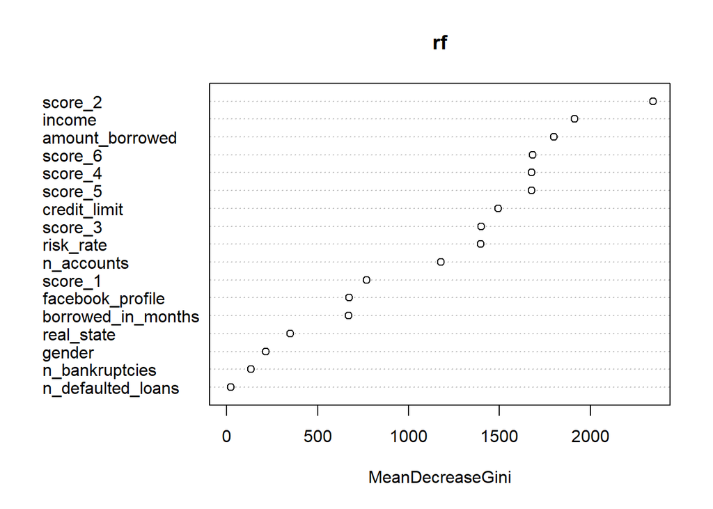

```r
formula <- default ~ score_1 + score_2 + score_3 + score_4 + score_5 + score_6 + risk_rate + amount_borrowed + borrowed_in_months + credit_limit + income + gender + facebook_profile + real_state + n_bankruptcies + n_defaulted_loans + n_accounts

rf <- randomForest(formula, na.omit(sample_data))

pred_rf <- predict(rf, validation, type='prob')
pred_rf <- pred_rf[,2]

# Metrics
auc_rf <- auc(pred_rf, validation$default)
logloss_rf <- logLoss(pred_rf[-which(is.na(pred_rf))],
                       ifelse(validation$default==0,0,1)[-which(is.na(pred_rf))])

varImpPlot(rf)
```

From the plot of the importance of the variables above, we see that the variables that impacts the most in the target variable are: *score_2*, *income* and *amount_borrowed*.

### Missing Values

The models attempted above however does not consider the amount of missing values in the test dataset. Using them will lead to NA probabilities as their predictors are missing, specially in the *credit_limit* variable.

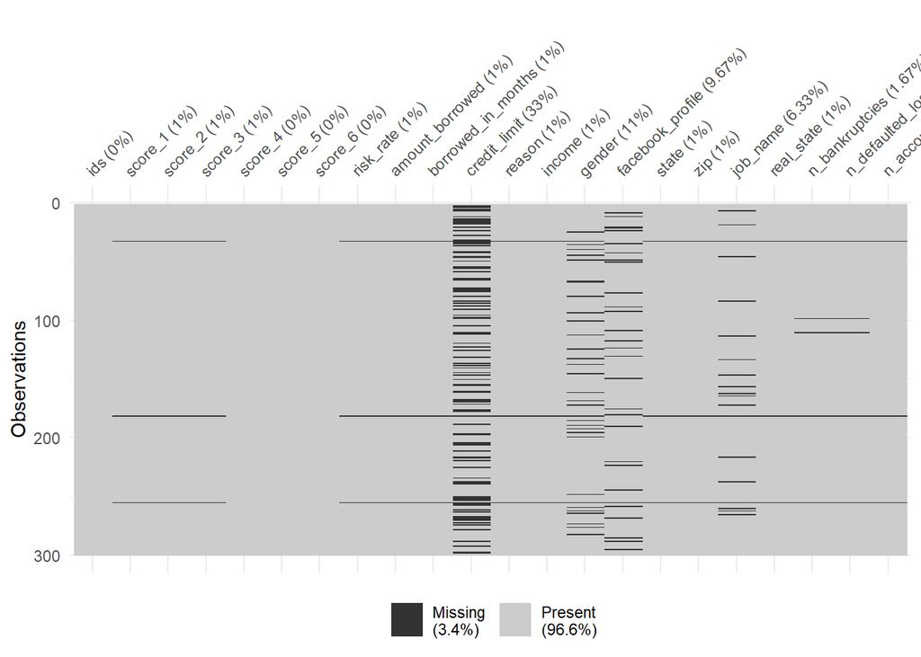

```r
# NA plot
vis_miss(head(test[,-which(names(test) %in% c("ok_since","channel", "sign", "n_issues"))],300))
```

The ways to overcome this are: dropping the features with high missing value rate, imputing the missing values with a constant value (like the mean), imputing the missing value using a machine learning algorith (like kNN) or trying an approach that deals with missing values, like the XGBoost. Here is an attempt with the latter:

### XGBoost

```r
format_data <- function(data) {

  data <- data %>% mutate_all(funs(replace(as.character(.), is.na(.), 0)))
  info_numeric <- data %>% select(-ids) %>% select_if(is.numeric)

  info_categorical <- model.matrix(~ score_1 + score_2 + borrowed_in_months + real_state + n_bankruptcies + n_defaulted_loans + facebook_profile + gender - 1, data)

  info_numeric <- cbind(info_numeric, info_categorical)

  mat <- data.matrix(info_numeric)

  return(mat)
}


mat_train <- format_data(sample_data)
mat_validation <- format_data(validation)
mat_test <- format_data(test)

# Missing
mat_test <- as.data.frame(mat_test)
not_in_train <- setdiff(names(as.data.frame(mat_test)),names(as.data.frame(mat_train)))
mat_test <- mat_test %>% select(-not_in_train)
mat_test <- data.matrix(mat_test)

# Labels
labels_train <- ifelse(sample_data$default==0,0,1)
labels_validation <- ifelse(validation$default==0,0,1)


# Matrices
dtrain <- xgb.DMatrix(data = mat_train, label= labels_train)
dvalidation <- xgb.DMatrix(data = mat_validation, label= labels_validation)
dtest <- xgb.DMatrix(data = mat_test, label = rep(NA,nrow(test)))

# Model
xgb <- xgboost(data = dtrain,
               nround = 4,
               objective = "binary:logistic")
pred_xgb <- predict(xgb, dvalidation)

# Metrics
auc_xgb <- auc(pred_xgb, validation$default)
logloss_xgb <- logLoss(pred_xgb,
                       ifelse(validation$default==0,0,1))
```

## Conclusions

```r
df <- data.frame('model' = c('Logistic Reg.', 'Logistic Reg. Binary Predictors', 'Random Forest', 'XGBoost'),
           'AUC' = c(auc_glm, auc_glm_bin, auc_rf, auc_xgb),
           'Log Loss' = c(logloss_glm, logloss_glm_bin, logloss_rf,logloss_xgb))

df %>%
  kable(caption='Metrics') %>%
  kable_styling()
```

Metrics

| model | AUC | Log.Loss |
| --- | --- | --- |
| Logistic Reg. | 0.729 | 0.602 |
| Logistic Reg. Binary Predictors | 0.720 | 0.614 |
| Random Forest | 0.708 | 1.322 |
| XGBoost | 0.711 | 0.630 |

The metric AUC is better when higher (best value equals to 1) and the Log Loss Score is better when lower (best value equals to 0). Altough the Logistic Regression scored better, it produces a lot of NA values, so we’ll go with the XGBoost that wasn’t so much worse and is able to predict a probability to every client.

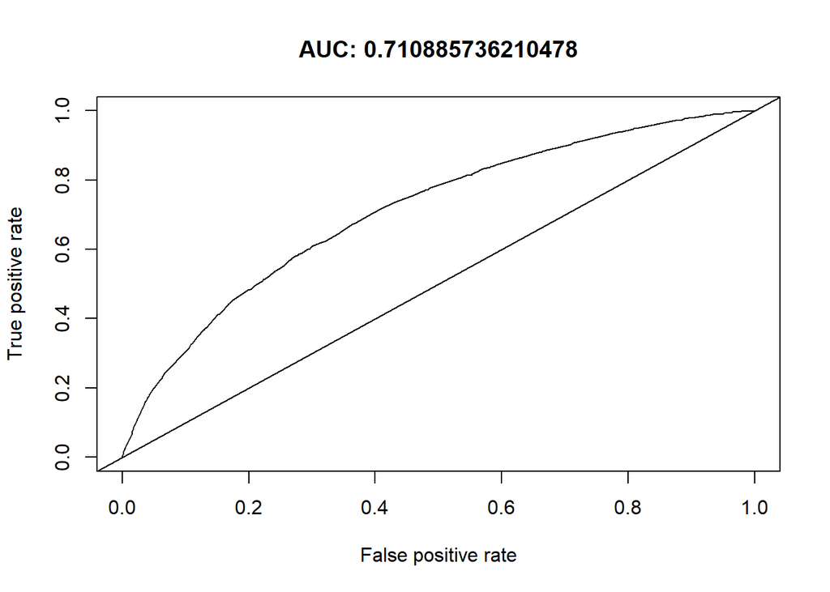

```
## integer(0)
```

```r
# ROC plot of the chosen model
roc_auc(pred_xgb, validation$default)
```

## Creating the csv file

```r
final_predictions <- data.frame('ids' = test$ids)
final_predictions$predictions <- predict(xgb,dtest)

write.csv(final_predictions, 'predictions.csv', row.names = FALSE)
```